# Question

Un estudiante tiene un vaso de forma cilíndrica. El vaso tiene una base circular de radio 35 cm y una altura de 61 cm, como se muestra en la figura.

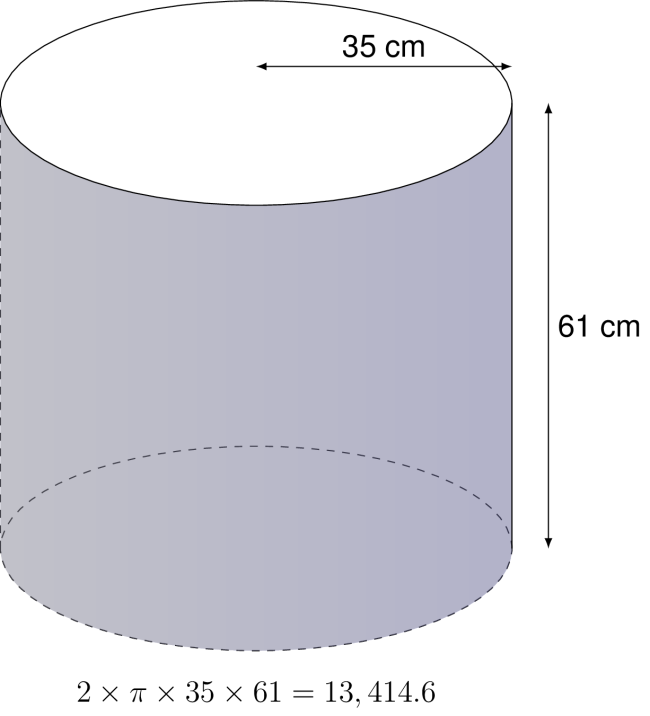

A partir de la información anterior, el estudiante plantea la siguiente operación:

$$2 \times \pi \times 35 \times 61 =
13,414.6$$

¿A qué corresponde el resultado de la anterior operación?

## Answerlist

- Al volumen del vaso
- Al área de la tapa del vaso
- Al perímetro de la tapa del vaso
- Al área lateral del vaso

# Solution

Para resolver este problema, debemos identificar qué cálculo se está realizando con la fórmula $2 \times \pi \times 35 \times 61 = 13,414.6$.

Analizando la fórmula:

- $2 \times \pi \times r$ corresponde al perímetro de la base circular del cilindro
- Al multiplicar este perímetro por la altura $h$, obtenemos el área lateral del cilindro

Por lo tanto, la fórmula $A_L = 2 \times \pi \times r \times h$ es la fórmula del área lateral de un cilindro.

Sustituyendo los valores:

- Radio de la base: $r = 35 \text{ cm}$
- Altura: $h = 61 \text{ cm}$

Calculamos:

$A_L = 2 \times \pi \times 35 \times 61 = 2 \times \pi \times 35 \times 61 = 13,414.6 \text{ cm}^2$

El resultado corresponde al área lateral del vaso cilíndrico, que es la superficie rectangular que forma la pared del cilindro (sin incluir las bases).

## Answerlist

- Falso
- Falso
- Falso
- Verdadero

# Meta-information

exname: Area_Lateral_Cilindro extype: schoice exsolution: 0001 exshuffle: TRUE